# 05-quantile-precision

Qianyi Sun

09/23/2019

# Introduction

As we all know, the median has an important meaning in doing some data analysis project. This is because the middle value of the data distribution can be used to indirectly represent data overall situation. But how to evaluate the median is very difficult.Thus now we begin to solve this problem.

For the distribution I need to calculate, we have already known that the random samples of size is N and the empirical sampling distribution should be at least 5000 draws. Then I need to Calculate the length of the middle 95% of the sampling distribution by calculating the difference between 2.5% and 97.5% percentiles of the sampling distribution.When I successfully calculate the length of the middle 95% of the sampling distribution, I still need to calculate the density (relative likelihood) corresponding to the pt**h quantiles.

# Problem solutions

## Standard normal distribution

### Calculate the length of the middle 95% of the sampling distribution

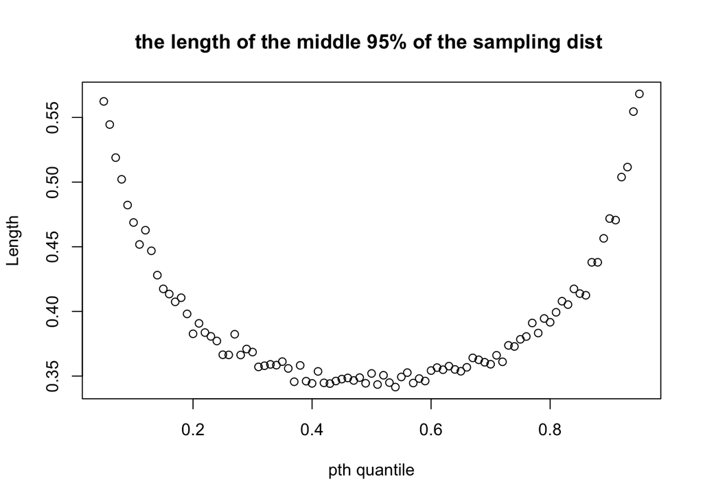

```r
N=200
draws=5000
mid.len1<-rep(NA,91)
pthquan<-rep(NA,draws)
p<-seq(0.05,0.95,length=91)
for(j in 1:91){
for(i in 1:draws){
  dist<-rnorm(N,mean=0,sd=1)
  pthquan[i]<-quantile(dist,p[j])

}
mid.len1[j]<-quantile(pthquan,0.975)-quantile(pthquan,0.025)
}
plot(p,mid.len1,main="the length of the middle 95% of the sampling dist ",xlab="pth quantile",ylab = "Length")
```

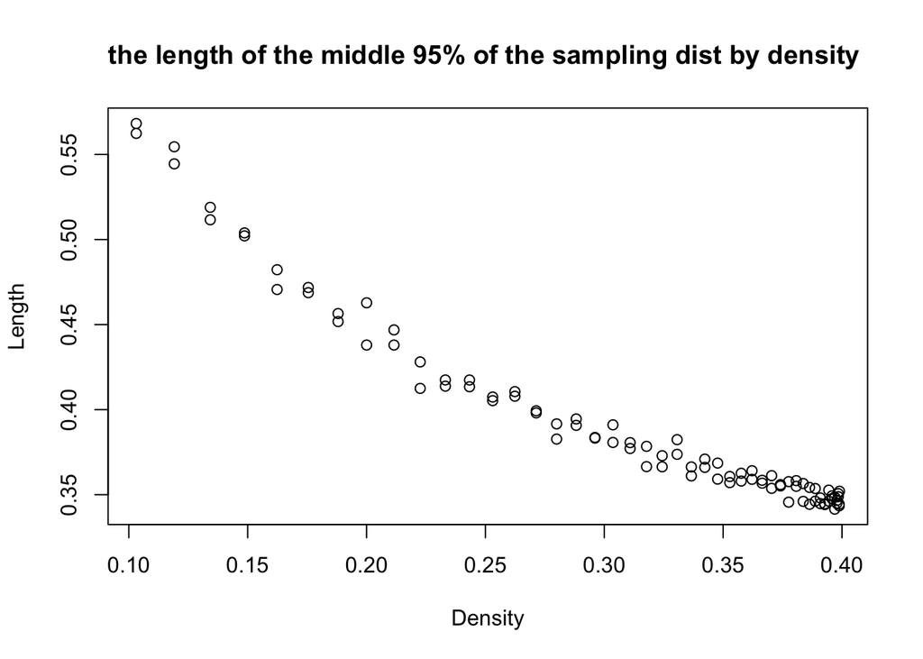

```r
x_value<-rep(NA,91)
x_density<-rep(NA,91)
for (i in 1:91){
  d=i*0.01+0.04
  x_value[i]<-qnorm(d)
}
for (i in 1:91){
x_density[i]<-dnorm(x_value[i])
}
plot(x_density,mid.len1,xlab="Density",ylab="Length",main="the length of the middle 95% of the sampling dist by density " )
```

## The exponential distribution with rate = 1

### Calculate the length of the middle 95% of the sampling distribution

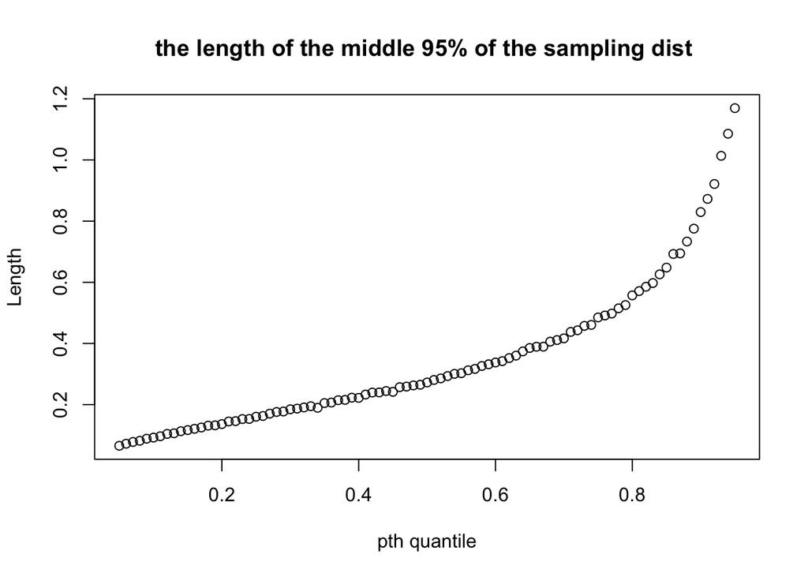

```r
N=200
draws=5000
mid.len2<-rep(NA,91)
pthquan<-rep(NA,draws)
p<-seq(0.05,0.95,length=91)
for(j in 1:91){
for(i in 1:draws){
  dist<-rexp(N, rate=1)
  pthquan[i]<-quantile(dist,p[j])

}
mid.len2[j]<-quantile(pthquan,0.975)-quantile(pthquan,0.025)
}
plot(p,mid.len2,main="the length of the middle 95% of the sampling dist ",xlab="pth quantile",ylab = "Length")
```

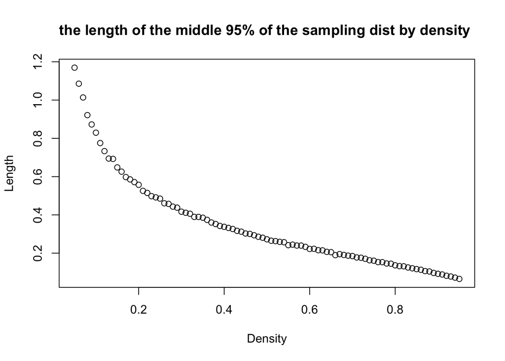

```r
x_value_2<-rep(NA,91)
x_density_2<-rep(NA,91)
for (i in 1:91){
  d=i*0.01+0.04
  x_value_2[i]<-qexp(d)
}
for (i in 1:91){
x_density_2[i]<-dexp(x_value_2[i])
}
plot(x_density_2,mid.len2,xlab="Density",ylab="Length",main="the length of the middle 95% of the sampling dist by density ")
```

## The mixture distribution 3

### Calculate the length of the middle 95% of the sampling distribution

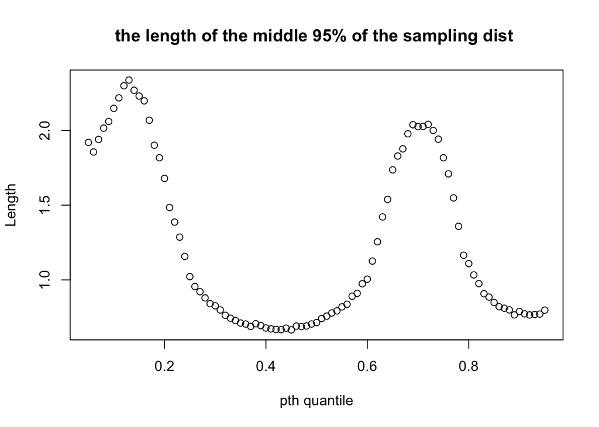

```r
rf3 <- function(N){
  G <- sample(0:2, N, replace = TRUE, prob = c(5,3,2))
  (G==0)*rnorm(N) + (G==1)*rnorm(N,4) + (G==2)*rnorm(N,-4,2)
}

pf3 <- function(x){
  .5*pnorm(x) + .3*pnorm(x,4) + .2*pnorm(x,-4,2)
}

df3 <- function(x){
  .5*dnorm(x) + .3*dnorm(x,4) + .2*dnorm(x,-4,2)
}
draws=5000
mid.len3<-rep(NA,91)   #why it has a red mark
pthquan<-rep(NA,draws)
p<-seq(0.05,0.95,length=91)
for(j in 1:91){
for(i in 1:draws){
  dist<-rf3(200)
  pthquan[i]<-quantile(dist,p[j])

}
mid.len3[j]<-quantile(pthquan,0.975)-quantile(pthquan,0.025)
}
plot(p,mid.len3,main="the length of the middle 95% of the sampling dist ",xlab="pth quantile",ylab = "Length")
```

When pth quantile is approaching the 40th quantile, the length of the middle 95% has nearly smallest value. Thus the 40th quantile has more precision. However, when pth quantile is approaching 5th, the length of the middle 95% has higher value. Thus the 5th has less precision.

### Calculate the density corresponding to the pt**h quantiles

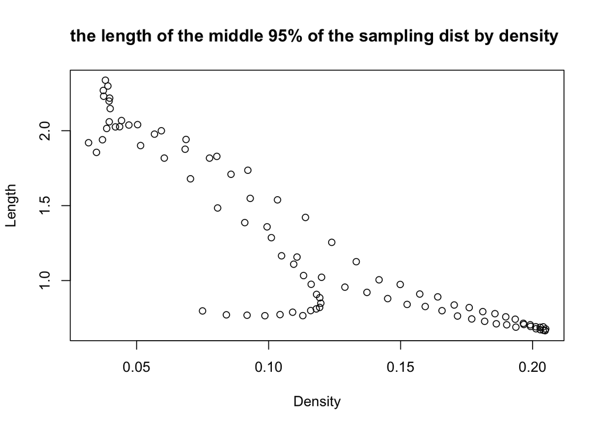

```r
p<-seq(0.05,0.95,length=91)
N=200
x_density<-rep(NA,91)
df3_3<-rep(NA,91)

for( i in 1:91){
  f1<-function(x){.5*pnorm(x) + .3*pnorm(x,4) + .2*pnorm(x,-4,2)-p[i]}
  x_density[i]<-uniroot(f1, lower = -200, upper = 200)
}

df3 <- function(x){
  .5*dnorm(x) + .3*dnorm(x,4) + .2*dnorm(x,-4,2)
}
for (i in seq_along(x_density)){
df3_3[i] <-df3(x_density[[i]])
}
plot(df3_3,mid.len3,xlab="Density",ylab="Length",main="the length of the middle 95% of the sampling dist by density ")
```

## The mixture distribution 4

### Calculate the length of the middle 95% of the sampling distribution

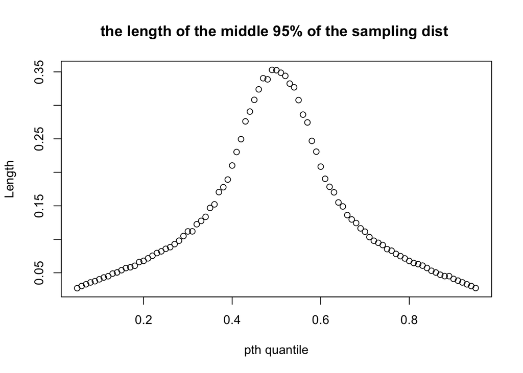

```r
rf4 <- function(N){
  G <- sample(0:1, N, replace = TRUE)
  (G==0)*rbeta(N,5,1) + (G==1)*rbeta(N,1,5)
}
draws=5000
mid.len4<-rep(NA,91)
pthquan<-rep(NA,draws)
p<-seq(0.05,0.95,length=91)
for(j in 1:91){
for(i in 1:draws){
  dist<-rf4(200)
  pthquan[i]<-quantile(dist,p[j])

}
mid.len4[j]<-quantile(pthquan,0.975)-quantile(pthquan,0.025)
}
plot(p,mid.len4,main="the length of the middle 95% of the sampling dist ",xlab="pth quantile",ylab = "Length")
```

When pth quantile is approaching the 5th quantile or 95th quantile, the length of the middle 95% has nearly smallest value. Thus the 5th quantile or 95th quantile has more precision. However, when pth quantile is approaching 50th, the length of the middle 95% has higher value compared to other quantiles. Thus the 50th has less precision.

### Calculate the density corresponding to the pt**h quantiles

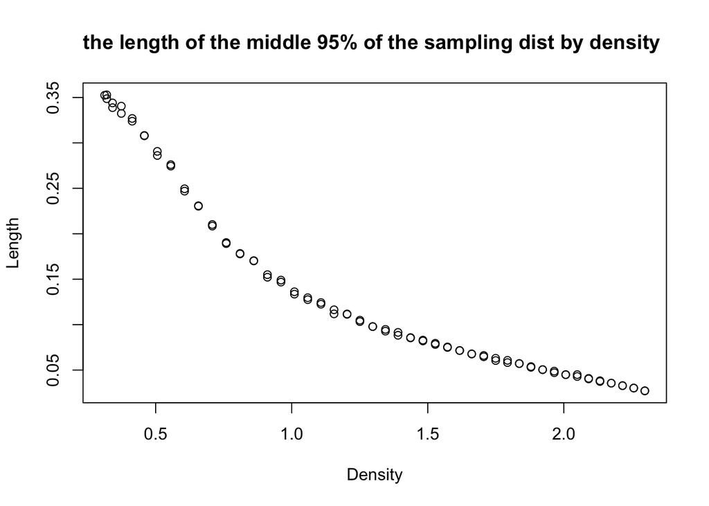

```r
pf4<-function(x){
  0.5*pbeta(x,5,1)+0.5*pbeta(x,1,5)
}
p<-seq(0.05,0.95,length=91)
N=200
x_density_4<-rep(NA,91)
df4_1<-rep(NA,91)

for( i in 1:91){
  f4<-function(x){0.5*pbeta(x,5,1)+0.5*pbeta(x,1,5)-p[i]}
  x_density_4[i]<-uniroot(f4, lower = -200, upper = 200)
}

df4 <- function(x){
  0.5*dbeta(x,5,1)+0.5*dbeta(x,1,5)
}
for (i in seq_along(x_density_4)){
df4_1[i] <-df4(x_density_4[[i]])
}
plot(df4_1,mid.len4,,xlab="Density",ylab="Length",main="the length of the middle 95% of the sampling dist by density ")
```

From the graph, we can know that with the decrease of pth quantile, the length is smaller. Thus the density is approaching to 2, the length has more precision. However, when the density is closer to 0.25, the length is less precisson.

# When does the median have the tightest sampling distribution?

For Distribution 1, when its quantile is 50th quantile, the median’s length of the middle 95% of the sampling distribution is nearly close to 0.35.At this quantile, the 50th quantile (median) has the highest density among other quantiles. Thus the median in distribution 1 will have the tightest sampling distribution at this time. But for other distributions, by obeserving their “the length of the middle 95% of the sampling distribution” graphs, we can clearly know that their medians do not have this attribute.

# Adding additional lines for selected distribution

In this point, I choose the standard normal distribution as the distribution to create a figure similar to the first one above, adding additional lines for N=400,800,1600.

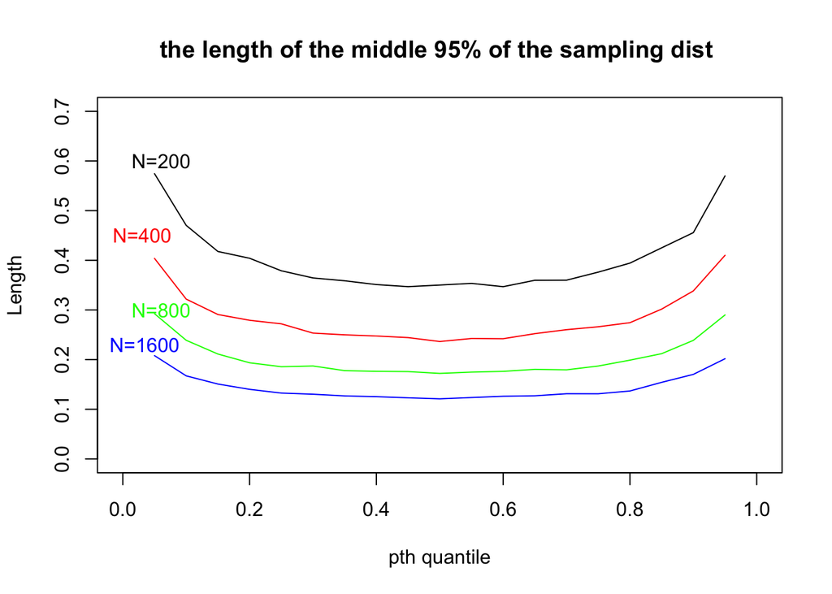

```r
N=200
draws=5000
mid.len1<-rep(NA,19)   #why it has a red mark
pthquan<-rep(NA,draws)
p<-seq(0.05,0.95,length=19)
for(j in 1:19){
for(i in 1:draws){
  dist<-rnorm(N,mean=0,sd=1)
  pthquan[i]<-quantile(dist,p[j])
}
mid.len1[j]<-quantile(pthquan,0.975)-quantile(pthquan,0.025)
}

N=400
mid.len1_2<-rep(NA,19)   #why it has a red mark
pthquan<-rep(NA,draws)
p<-seq(0.05,0.95,length=19)
for(j in 1:19){
for(i in 1:draws){
  dist<-rnorm(N,mean=0,sd=1)
  pthquan[i]<-quantile(dist,p[j])
}
mid.len1_2[j]<-quantile(pthquan,0.975)-quantile(pthquan,0.025)
}

N=800
mid.len1_3<-rep(NA,19)   #why it has a red mark
pthquan<-rep(NA,draws)
p<-seq(0.05,0.95,length=19)
for(j in 1:19){
for(i in 1:draws){
  dist<-rnorm(N,mean=0,sd=1)
  pthquan[i]<-quantile(dist,p[j])
}
mid.len1_3[j]<-quantile(pthquan,0.975)-quantile(pthquan,0.025)
}

N=1600
mid.len1_4<-rep(NA,19)   #why it has a red mark
pthquan<-rep(NA,draws)
p<-seq(0.05,0.95,length=19)
for(j in 1:19){
for(i in 1:draws){
  dist<-rnorm(N,mean=0,sd=1)
  pthquan[i]<-quantile(dist,p[j])

}
mid.len1_4[j]<-quantile(pthquan,0.975)-quantile(pthquan,0.025)
}

plot(p,mid.len1,type = "l",xlim = c(0,1.0),ylim=c(0,0.7),main="the length of the middle 95% of the sampling dist ",xlab="pth quantile",ylab = "Length")
lines(p,mid.len1_2,type="l",col="red")
lines(p,mid.len1_3,type="l",col="green")
lines(p,mid.len1_4,type="l",col="blue")

text(0.2,0.6,"N=200",2,col="black")
text(0.17,0.45,"N=400",2,col="red")
text(0.2,0.3,"N=800",2,col="green")
text(0.2,0.23,"N=1600",2,col="blue")
```

## Analysing the graph above

By analyzing the graph above, we can know that when N is larger, the length of the middle 95% of the sampling distribution is less and has the more tight sampling distribution. It also means that the N is larger, the precision is more.